# Predict whether a customer eligible for the PERSONAL LOAN or NOT

## Introduction

In this notebook a machine learning classifier is built that can predict whethere a customer is eligible for a personal or not based on multiple features such as age, experience, education, income, family size, spendings on credit card, mortgages, security accounts, deposits etc.Tthe data used in this example is obtained from an universal bank. The notebook will be presented as follow :

- Data Loading
- Data Preprocessing & Cleansing
- Exploratory data analysis & Visualisation
- Data Modeling
- Evaluting the Model

```python
data_path = "/Volumes/RAMESH/Deploy/personal_loan_eligibility_predictor_clf/Data/"
```

## Dataset Description

- ID : Customer ID
- Age : Customer's age in completed years
- Experience : #years of professional experience
- Income : Annual income of the customer in thousands dollars
- ZIP Code : Home Address ZIP code.
- Family : Family size of the customer
- CCAvg : Avg. spending on credit cards per month in thousands dollars
- Education : Education Level.
  - 1: Undergrad
  - 2: Graduate
  - 3: Advanced/Professional
- Mortgage : Value of house mortgage if any, in thousands dollars
- **Personal Loan** : **Did this customer accept the personal loan offered in the last campaign? Target Attribute**
- Securities Account : Does the customer have a securities account with the bank?
  - 0: No
  - 1: Yes
- CD Account : Does the customer have a certificate of deposit (CD) account with the bank?
  - 0: No
  - 1: Yes
- Online : Does the customer use internet banking facilities?
  - 0: No
  - 1: Yes
- CreditCard : Does the customer use a credit card issued by UniversalBank?
  - 0: No
  - 1: Yes

```python
import numpy as np
import pandas as pd
from sklearn.model_selection import train_test_split
import seaborn as sns
import matplotlib.pyplot as plt
%matplotlib inline
```

```python
bankDF = pd.read_csv(f"{data_path}UniversalBank.csv")
```

Verify the first few rows of the data

```python
bankDF.head()
```

|  | ID | Age | Experience | Income | ZIP Code | Family | CCAvg | Education | Mortgage | Personal Loan | Securities Account | CD Account | Online | CreditCard |
| --- | --- | --- | --- | --- | --- | --- | --- | --- | --- | --- | --- | --- | --- | --- |
| 0 | 1 | 25 | 1 | 49 | 91107 | 4 | 1.6 | 1 | 0 | 0 | 1 | 0 | 0 | 0 |
| 1 | 2 | 45 | 19 | 34 | 90089 | 3 | 1.5 | 1 | 0 | 0 | 1 | 0 | 0 | 0 |
| 2 | 3 | 39 | 15 | 11 | 94720 | 1 | 1.0 | 1 | 0 | 0 | 0 | 0 | 0 | 0 |
| 3 | 4 | 35 | 9 | 100 | 94112 | 1 | 2.7 | 2 | 0 | 0 | 0 | 0 | 0 | 0 |
| 4 | 5 | 35 | 8 | 45 | 91330 | 4 | 1.0 | 2 | 0 | 0 | 0 | 0 | 0 | 1 |

Verify the last few rows of the data

```python
bankDF.tail()
```

|  | ID | Age | Experience | Income | ZIP Code | Family | CCAvg | Education | Mortgage | Personal Loan | Securities Account | CD Account | Online | CreditCard |
| --- | --- | --- | --- | --- | --- | --- | --- | --- | --- | --- | --- | --- | --- | --- |
| 4995 | 4996 | 29 | 3 | 40 | 92697 | 1 | 1.9 | 3 | 0 | 0 | 0 | 0 | 1 | 0 |
| 4996 | 4997 | 30 | 4 | 15 | 92037 | 4 | 0.4 | 1 | 85 | 0 | 0 | 0 | 1 | 0 |
| 4997 | 4998 | 63 | 39 | 24 | 93023 | 2 | 0.3 | 3 | 0 | 0 | 0 | 0 | 0 | 0 |
| 4998 | 4999 | 65 | 40 | 49 | 90034 | 3 | 0.5 | 2 | 0 | 0 | 0 | 0 | 1 | 0 |
| 4999 | 5000 | 28 | 4 | 83 | 92612 | 3 | 0.8 | 1 | 0 | 0 | 0 | 0 | 1 | 1 |

Verify the shape of the data

```python
bankDF.shape
```

```
(5000, 14)
```

Verify the structure of the data

```python
bankDF.info()
```

```
<class 'pandas.core.frame.DataFrame'>
RangeIndex: 5000 entries, 0 to 4999
Data columns (total 14 columns):
ID                    5000 non-null int64
Age                   5000 non-null int64
Experience            5000 non-null int64
Income                5000 non-null int64
ZIP Code              5000 non-null int64
Family                5000 non-null int64
CCAvg                 5000 non-null float64
Education             5000 non-null int64
Mortgage              5000 non-null int64
Personal Loan         5000 non-null int64
Securities Account    5000 non-null int64
CD Account            5000 non-null int64
Online                5000 non-null int64
CreditCard            5000 non-null int64
dtypes: float64(1), int64(13)
memory usage: 547.0 KB
```

Verify the summary statistics of the data

```python
bankDF.describe().T
```

|  | count | mean | std | min | 25% | 50% | 75% | max |
| --- | --- | --- | --- | --- | --- | --- | --- | --- |
| ID | 5000.0 | 2500.500000 | 1443.520003 | 1.0 | 1250.75 | 2500.5 | 3750.25 | 5000.0 |
| Age | 5000.0 | 45.338400 | 11.463166 | 23.0 | 35.00 | 45.0 | 55.00 | 67.0 |
| Experience | 5000.0 | 20.104600 | 11.467954 | -3.0 | 10.00 | 20.0 | 30.00 | 43.0 |
| Income | 5000.0 | 73.774200 | 46.033729 | 8.0 | 39.00 | 64.0 | 98.00 | 224.0 |
| ZIP Code | 5000.0 | 93152.503000 | 2121.852197 | 9307.0 | 91911.00 | 93437.0 | 94608.00 | 96651.0 |
| Family | 5000.0 | 2.396400 | 1.147663 | 1.0 | 1.00 | 2.0 | 3.00 | 4.0 |
| CCAvg | 5000.0 | 1.937938 | 1.747659 | 0.0 | 0.70 | 1.5 | 2.50 | 10.0 |
| Education | 5000.0 | 1.881000 | 0.839869 | 1.0 | 1.00 | 2.0 | 3.00 | 3.0 |
| Mortgage | 5000.0 | 56.498800 | 101.713802 | 0.0 | 0.00 | 0.0 | 101.00 | 635.0 |
| Personal Loan | 5000.0 | 0.096000 | 0.294621 | 0.0 | 0.00 | 0.0 | 0.00 | 1.0 |
| Securities Account | 5000.0 | 0.104400 | 0.305809 | 0.0 | 0.00 | 0.0 | 0.00 | 1.0 |
| CD Account | 5000.0 | 0.060400 | 0.238250 | 0.0 | 0.00 | 0.0 | 0.00 | 1.0 |
| Online | 5000.0 | 0.596800 | 0.490589 | 0.0 | 0.00 | 1.0 | 1.00 | 1.0 |
| CreditCard | 5000.0 | 0.294000 | 0.455637 | 0.0 | 0.00 | 0.0 | 1.00 | 1.0 |

Verify the unique value counts in each column

```python
bankDF.nunique()
```

```
ID                    5000
Age                     45
Experience              47
Income                 162
ZIP Code               467
Family                   4
CCAvg                  108
Education                3
Mortgage               347
Personal Loan            2
Securities Account       2
CD Account               2
Online                   2
CreditCard               2
dtype: int64
```

Verify for the null values

```python
bankDF.isnull().sum()
```

```
ID                    0
Age                   0
Experience            0
Income                0
ZIP Code              0
Family                0
CCAvg                 0
Education             0
Mortgage              0
Personal Loan         0
Securities Account    0
CD Account            0
Online                0
CreditCard            0
dtype: int64
```

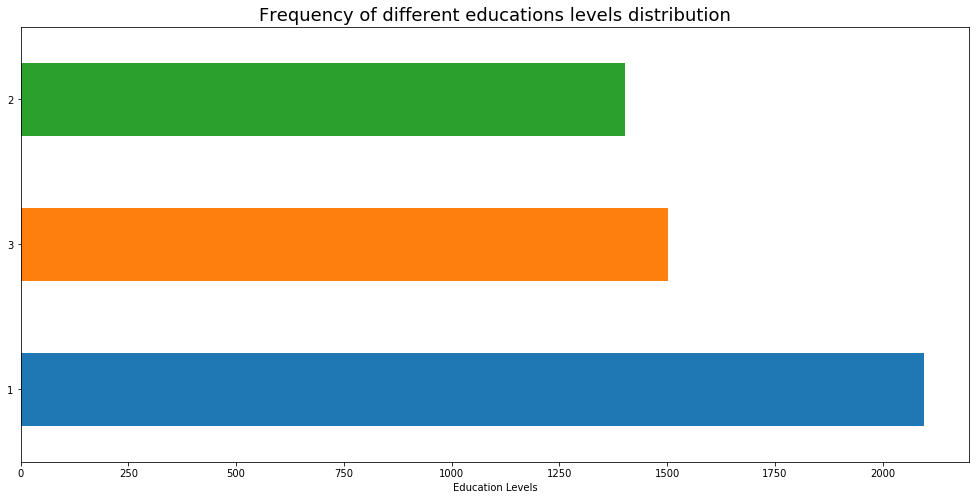

```python
plt.figure(figsize=(17,8))
bankDF.Education.value_counts().plot(kind='barh')
plt.xlabel('Education Levels')
plt.title("Frequency of different educations levels distribution",fontsize=18)
plt.show()
```

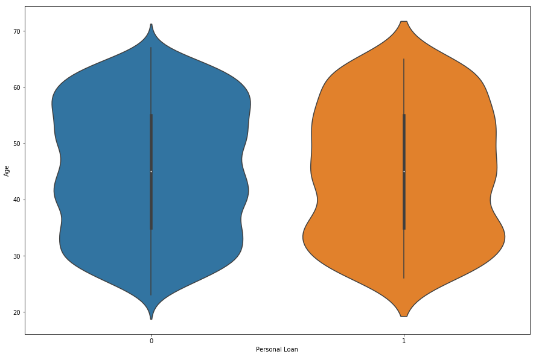

```python
f, ax = plt.subplots(figsize=(15, 10))
sns.violinplot(data = bankDF, x='Personal Loan', y='Age')
plt.show()
```

```python
bankDF.dtypes
```

```
ID                      int64
Age                     int64
Experience              int64
Income                  int64
ZIP Code                int64
Family                  int64
CCAvg                 float64
Education               int64
Mortgage                int64
Personal Loan           int64
Securities Account      int64
CD Account              int64
Online                  int64
CreditCard              int64
dtype: object
```

```python
bankDF.Education = bankDF.Education.astype('category')
```

```python
bankDF.dtypes
```

```
ID                       int64
Age                      int64
Experience               int64
Income                   int64
ZIP Code                 int64
Family                   int64
CCAvg                  float64
Education             category
Mortgage                 int64
Personal Loan            int64
Securities Account       int64
CD Account               int64
Online                   int64
CreditCard               int64
dtype: object
```

```python
X = bankDF[['Age', 'Experience', 'Income', 'Family', 'CCAvg',  'Mortgage',
            'Securities Account', 'CD Account', 'Online', 'CreditCard', 'Education']]
Y = bankDF['Personal Loan']
X = pd.get_dummies(data=X)
```

```python
# now we use the train_test_split function already available in sklearn library to split our data set
X_train, X_test, Y_train, Y_test = train_test_split(X, Y, test_size = .20, random_state = 2018)
```

### Prediction using KNN Classifier

```python
from sklearn import neighbors
# the value of n_neighbors will be changed when we plot the histogram showing the lowest RMSE value
knn = neighbors.KNeighborsClassifier(n_neighbors=6)
knn.fit(X_train, Y_train)

predicted = knn.predict(X_test)

# Verify accuracy
from sklearn.metrics import accuracy_score
print(accuracy_score(Y_test, predicted))
```

```
0.926
```

```python
from sklearn.ensemble import GradientBoostingClassifier
# Create adaboost-decision tree classifer object
GBM_model = GradientBoostingClassifier(n_estimators=200,
                                       max_depth=5,
                                       learning_rate=0.1)

%time GBM_model.fit(X_train, Y_train)

# Predict on Test
y_preds_train = GBM_model.predict(X_train)
y_preds_test = GBM_model.predict(X_test)

print("Train Accuracy", accuracy_score(Y_train, y_preds_train))
print("Test Accuracy", accuracy_score(Y_test, y_preds_test))
```

```
CPU times: user 1 s, sys: 4.5 ms, total: 1.01 s
Wall time: 1.01 s
Train Accuracy 1.0
Test Accuracy 0.994
```

```python
#!pip install xgboost
from xgboost import XGBClassifier

# Create adaboost-decision tree classifer object
XGB_model = XGBClassifier(colsample_bytree = 0.6,
                          n_estimators=200,
                          max_depth=10)

%time XGB_model.fit(X_train, Y_train)

# Predict on Test
y_preds_train = XGB_model.predict(X_train)
y_preds_test = XGB_model.predict(X_test)

print("Train Accuracy", accuracy_score(Y_train, y_preds_train))
print("Test Accuracy", accuracy_score(Y_test, y_preds_test))
```

```
CPU times: user 510 ms, sys: 2.37 ms, total: 513 ms
Wall time: 512 ms
Train Accuracy 1.0
Test Accuracy 0.994
```

## Let's predict an observation never seen before

To do that we first build a fucntion that takes a simple user input and transform it to a one hot encoding.

```python
# user_input1 = [25, 1, 49, 4, 1.6, 0, 1, 0, 0, 0, 1]

# Target: 0
user_input1 = {'Age': 25,
               'Experience': 1,
               'Income': 49,
               'Family': 4,
               'CCAvg': 1.6,
               'Mortgage': 0,
               'Securities Account': 1,
               'CD Account': 0,
               'Online': 0,
               'CreditCard': 0,
               'Education': 1,
              }

# Target: 1
user_input2 = {'Age': 34,
               'Experience': 9,
               'Income': 180,
               'Family': 1,
               'CCAvg': 8.9,
               'Mortgage': 0,
               'Securities Account': 0,
               'CD Account': 0,
               'Online': 0,
               'CreditCard': 0,
               'Education': 3,
              }

# Target: 0
user_input3 = {'Age': 60,
               'Experience': 30,
               'Income': 22,
               'Family': 1,
               'CCAvg': 1.5,
               'Mortgage': 0,
               'Securities Account': 0,
               'CD Account': 0,
               'Online': 1,
               'CreditCard': 1,
               'Education': 3,
              }

# Target: 1
user_input4 = {'Age': 38,
               'Experience': 14,
               'Income': 130,
               'Family': 4,
               'CCAvg': 4.7,
               'Mortgage': 134,
               'Securities Account': 0,
               'CD Account': 0,
               'Online': 0,
               'CreditCard': 0,
               'Education': 3,
              }
```

```python
def input_to_one_hot(data):
    # initialize the target vector with zero values
    enc_input = np.zeros(13)
    # set the numerical input as they are
    enc_input[0] = data['Age']
    enc_input[1] = data['Experience']
    enc_input[2] = data['Income']
    enc_input[3] = data['Family']
    enc_input[4] = data['CCAvg']
    enc_input[5] = data['Mortgage']
    enc_input[6] = data['Securities Account']
    enc_input[7] = data['CD Account']
    enc_input[8] = data['Online']
    enc_input[9] = data['CreditCard']
    ##################### Education #########################
    # get the array of Education categories
    #marks = bankDF.Education.unique()
    #print(marks)
    # redefine the the user inout to match the column name
    redefinded_user_input = 'Education_'+str(data['Education'])
    # search for the index in columns name list
    edu_column_index = X.columns.tolist().index(redefinded_user_input)
    # print(edu_column_index)
    # fullfill the found index with 1
    enc_input[edu_column_index] = 1
    return enc_input
```

```python
print(input_to_one_hot(user_input1))
print(input_to_one_hot(user_input2))
print(input_to_one_hot(user_input3))
print(input_to_one_hot(user_input4))
```

```
[25.   1.  49.   4.   1.6  0.   1.   0.   0.   0.   1.   0.   0. ]
[ 34.    9.  180.    1.    8.9   0.    0.    0.    0.    0.    0.    0.
   1. ]
[60.  30.  22.   1.   1.5  0.   0.   0.   1.   1.   0.   0.   1. ]
[ 38.   14.  130.    4.    4.7 134.    0.    0.    0.    0.    0.    0.
   1. ]
```

```python
input_vector1 = input_to_one_hot(user_input1)
input_vector2 = input_to_one_hot(user_input2)
input_vector3 = input_to_one_hot(user_input3)
input_vector4 = input_to_one_hot(user_input4)
print(input_vector1)
print(input_vector2)
print(input_vector3)
print(input_vector4)
```

```
[25.   1.  49.   4.   1.6  0.   1.   0.   0.   0.   1.   0.   0. ]
[ 34.    9.  180.    1.    8.9   0.    0.    0.    0.    0.    0.    0.
   1. ]
[60.  30.  22.   1.   1.5  0.   0.   0.   1.   1.   0.   0.   1. ]
[ 38.   14.  130.    4.    4.7 134.    0.    0.    0.    0.    0.    0.
   1. ]
```

```python
loan_pred = GBM_model.predict([input_vector1])
loan_pred
```

```
array([0])
```

```python
loan_pred = GBM_model.predict([input_vector2])
loan_pred
```

```
array([1])
```

```python
loan_pred = GBM_model.predict([input_vector3])
loan_pred
```

```
array([0])
```

```python
loan_pred = GBM_model.predict([input_vector4])
loan_pred
```

```
array([1])
```

### Save the Model

```python
from sklearn.externals import joblib
joblib.dump(GBM_model, 'gbm_clf_model_loan_prediction.pkl')
```

```
['gbm_clf_model_loan_prediction.pkl']
```

```python
gbm_model = joblib.load('gbm_clf_model_loan_prediction.pkl')
```

```python
if gbm_model.predict([input_vector4])[0] == 0:
    print("Not Eligible for Personal Loan")
else:
    print("Eligible for Personal Loan")
```

```
Eligible for Personal Loan
```